# Partisan Dating Preferences Experiment

This project is an experiment I ran in grad school. I was interested in how partisanship impacted dating preferences. In order to study this I set up a survey experiment. In the experiment I had participants view 9 dating profiles. The information on the dating profile, including the partisanship, was randomized for each participant. The respondent indicated on a scale of 1-7 how much they would be interested in dating this individual. I recorded political info for the respondent as well. I predcited that individuals who were partisan (Republicans or Democrats) would be less interested in profiles with opposing partisanship. However I did not think finding a member of the same party would be much of a boost. The profiles were randomly assigned to be Republican, Democrat, or blank. The blank served as the control in the experiment.

```r
rm(list = ls())

library(dplyr)

setwd("C:/Users/cayde/OneDrive/Data Science/R Projects/Dating Preferences")

dating_data <- read.csv("Dating Preferences Data.csv")
```

Because I am interested in how the political beliefs of the respondents effects their dating preferences I drop all respondents who did not provide their political information.

```r
dating_data <- filter(dating_data, !is.na(Ideology) & !is.na(Party.ID)) #removing non response for party and ideology
dating_data <- dating_data[,-c(1:10)] #removing metadata
```

```r
#getting descriptive means
colMeans(dating_data[,names(dating_data) %in% c("Age", "Ideology", "Sex", "Party.ID", "Republican.Therm", "Democrat.Therm")])
```

```
             Sex              Age         Party.ID         Ideology   Democrat.Therm Republican.Therm
       0.3434343               NA        3.3434343        3.2929293       64.4646465       44.6363636
```

In the data each profile has it’s own variable name. I have 9 profiles of men and 9 profiles of women. Each profile has an assigned partisanship. The profiles are have names X1 through X9. F stands for female and M stands for Male. R stands for Republican, D stands for Democrat, and C stands for control. The variable X1FD_1 would indicate that the first female profile was assigned democrat. X6MC_1 indicates that the 6th male profile was assigned control. This naming scheme allows me to know exactly which profiles each respondent saw.

In the code below I create an average rating for the profiles by their partisanship.

```r
#Creating variables that are averages of respondents rating for Democrat, Republican and Control

dating_data$democrat_avg <- rowMeans(subset(dating_data, select = c(X1FD_1,X2FD_1,X3FD_1,X4FD_1,X5FD_1,X6FD_1,X7FD_1,X8FD_1,X9FD_1,X1MD_1,X2MD_1,X3MD_1,X4MD_1,X5MD_1,X6MD_1,X7MD_1,X8MD_1,X9MD_1)), na.rm = TRUE)

dating_data$republican_avg <- rowMeans(subset(dating_data, select = c(X1FR_1,X2FR_1,X3FR_1,X4FR_1,X5FR_1,X6FR_1,X7FR_1,X8FR_1,X9FR_1,X1MR_1,X2MR_1,X3MR_1,X4MR_1,X5MR_1,X6MR_1,X7MR_1,X8MR_1,X9MR_1)), na.rm = TRUE)

dating_data$control_avg <- rowMeans(subset(dating_data, select = c(X1FC_1,X2FC_1,X3FC_1,X4FC_1,X5FC_1,X6FC_1,X7FC_1,X8FC_1,X9FC_1,X1MC_1,X2MC_1,X3MC_1,X4MC_1,X5MC_1,X6MC_1,X7MC_1,X8MC_1,X9MC_1)), na.rm = TRUE)
```

I would like to remove the profiles after I have aggregated the data so that I will have a clean data set. The profiles all begin with X. Here I rename some variables that have an X in them so I can easily identify the profile vars with the letter X.

```r
# All profile variables start with "X"
# Renaming other variables that have an "X" in them to isolate the profiles
dating_data <- rename(dating_data, "Orientation" = "Sexual.Orientation")
dating_data <- rename(dating_data, "Gender" = "Sex")
```

Before I remove the profiles I want to aggregate them again. But rather than having a continuous measure I would like to convert it to a binary one (interested vs. not interested). Many dating apps have a simple binary feature (left swipe vs. right swipe). This just gives me another way of reporting the data.

```r
profile_vars <- names(select(dating_data, contains("X")))

# Converting Likert scale to binary variable

for(column in profile_vars){
  dating_data[,column] <- recode(dating_data[,column], `7` = 1,
                               `6` = 1,
                               `5` = 1,
                               `4` = 1,
                               `3` = 0,
                               `2` = 0,
                               `1` = 0)
}
#Creating variables that are averages of respondents rating for Democrat, Republican and Control

dating_data$democrat_interest <- rowMeans(subset(dating_data, select = c(X1FD_1,X2FD_1,X3FD_1,X4FD_1,X5FD_1,X6FD_1,X7FD_1,X8FD_1,X9FD_1,X1MD_1,X2MD_1,X3MD_1,X4MD_1,X5MD_1,X6MD_1,X7MD_1,X8MD_1,X9MD_1)), na.rm = TRUE)
dating_data$republican_interest <- rowMeans(subset(dating_data, select = c(X1FR_1,X2FR_1,X3FR_1,X4FR_1,X5FR_1,X6FR_1,X7FR_1,X8FR_1,X9FR_1,X1MR_1,X2MR_1,X3MR_1,X4MR_1,X5MR_1,X6MR_1,X7MR_1,X8MR_1,X9MR_1)), na.rm = TRUE)
dating_data$control_interest <- rowMeans(subset(dating_data, select = c(X1FC_1,X2FC_1,X3FC_1,X4FC_1,X5FC_1,X6FC_1,X7FC_1,X8FC_1,X9FC_1,X1MC_1,X2MC_1,X3MC_1,X4MC_1,X5MC_1,X6MC_1,X7MC_1,X8MC_1,X9MC_1)), na.rm = TRUE)
```

After recoding the profiles and aggregating them to a variable called ‘interest’ I now remove all the profiles as well as any observations with missing data.

```r
# Removing individual profiles

dating_data <- select(dating_data, !contains("X"))

dating_data <- na.omit(dating_data)
```

I also need to convert the 7 pt Party ID to the typical Republican, Democrat, and Independent. This makes the results of the experiment more easy to report.

```r
#converting 7 point PID to party

dating_data$Party <- NA
dating_data$Party[dating_data$Party.ID < 4] <- "Democrat"
dating_data$Party[dating_data$Party.ID == 4] <- "Independent"
dating_data$Party[dating_data$Party.ID > 4] <- "Republican"
```

The final transformation I need to make to the data is to convert it into ‘long’ format. Currently it is in a wide format. Each respondent has an average rating for Democrat profiles, Republican profiles, and control profiles. These represent 3 different columns. In order to do an ANOVA, I need to put the data into long format. One column will indicate the partisanship of the profile and another column will have the average rating. There will be three rows per respondent. In this manner I can treat the rating of the profile as a dependent variable and the partisanship of the profile as an independent variable.

```r
# AOV

# Converting data to 'long' format
dating_data_long <- gather(dating_data, key = "partisanship_of_profile", value = "average_rating", democrat_avg:control_avg)
```

Before doing the analysis let’s visualize the data

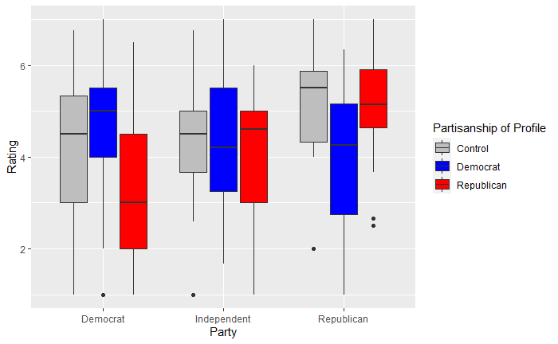

```r
ggplot(dating_data_long, aes(y=average_rating, x=Party, fill = partisanship_of_profile)) +
  geom_boxplot() +
  labs(y="Rating") +
  scale_fill_manual(name = "Partisanship of Profile",
                    labels = c("Control", "Democrat", "Republican"),
                    values = c("gray", "blue", "red"))
```

It appears as though Democrats are significantly less interested in dating Republicans and vice versa. Independents on the other hand do no have a preference. Interestingly the differences between the control and the in-party profiles show little difference for both Democrats and Republicans. Let’s perform statistical analysis to see if these effects are significant.

Now I move on to the ANOVA. I could simply put partisanship as a control variable, but I am interested in seeing the differences between Republicans and Democrats. Perhaps one party is more concerned with whom they data than the other party. I run an ANOVA regressing the rating on partisanship of the profile. Remember their are three types of profiles (Democrats, Republicans, and control), thus I need an ANOVA rather than the t-test.

Looking at the Democratic respondents we can see that the partisanship of the profile was a significant predictor of their rating. Performing Tukey HSD tests we see where the differences lie. As predicted Republican profiles were viewed much less favorably compare to control and Democratic profiles. However, Democrats did not prefer Democrat profiles compared to control profiles.

```r
dem_pref <- aov(lm(average_rating ~ partisanship_of_profile, data = dating_data_long[dating_data_long$Party == "Democrat",]))
summary(dem_pref)
```

```
                         Df Sum Sq Mean Sq F value   Pr(>F)
partisanship_of_profile   2  62.57  31.287    15.5 8.02e-07 ***
Residuals               144 290.72   2.019
---
Signif. codes:  0 ‘***’ 0.001 ‘**’ 0.01 ‘*’ 0.05 ‘.’ 0.1 ‘ ’ 1
```

```r
TukeyHSD(dem_pref)
```

```
  Tukey multiple comparisons of means
    95% family-wise confidence level

Fit: aov(formula = lm(average_rating ~ partisanship_of_profile, data = dating_data_long[dating_data_long$Party == "Democrat", ]))

$partisanship_of_profile
                                  diff        lwr        upr     p adj
democrat_avg-control_avg     0.5452381 -0.1345784  1.2250546 0.1425405
republican_avg-control_avg  -1.0283771 -1.7081936 -0.3485605 0.0013436
republican_avg-democrat_avg -1.5736152 -2.2534317 -0.8937986 0.0000005
```

I do not have any expect and strong effects for independents. While it is possible that independents dislike both Republican and Democratic profiles this would make dating very difficult for them. Indeed, I find no significant effects for partisanship and the TukeyHSD tests show that there are no large differences between the groups.

```r
ind_pref <- aov(lm(average_rating ~ partisanship_of_profile, data = dating_data_long[dating_data_long$Party == "Independent",]))
summary(ind_pref)
```

```
                        Df Sum Sq Mean Sq F value Pr(>F)
partisanship_of_profile  2   0.41  0.2064   0.114  0.892
Residuals               60 108.24  1.8040
```

```r
TukeyHSD(ind_pref)
```

```
  Tukey multiple comparisons of means
    95% family-wise confidence level

Fit: aov(formula = lm(average_rating ~ partisanship_of_profile, data = dating_data_long[dating_data_long$Party == "Independent", ]))

$partisanship_of_profile
                                   diff       lwr       upr     p adj
democrat_avg-control_avg     0.01111111 -0.985010 1.0072322 0.9996039
republican_avg-control_avg  -0.16587302 -1.161994 0.8302481 0.9156398
republican_avg-democrat_avg -0.17698413 -1.173105 0.8191370 0.9045573
```

```r
rep_pref <- aov(lm(average_rating ~ partisanship_of_profile, data = dating_data_long[dating_data_long$Party == "Republican",]))
summary(rep_pref)
```

```
                        Df Sum Sq Mean Sq F value Pr(>F)
partisanship_of_profile  2  13.08   6.538   3.825  0.028 *
Residuals               54  92.31   1.709
---
Signif. codes:  0 ‘***’ 0.001 ‘**’ 0.01 ‘*’ 0.05 ‘.’ 0.1 ‘ ’ 1
```

```r
TukeyHSD(rep_pref)
```

```
  Tukey multiple comparisons of means
    95% family-wise confidence level

Fit: aov(formula = lm(average_rating ~ partisanship_of_profile, data = dating_data_long[dating_data_long$Party == "Republican", ]))

$partisanship_of_profile
                                   diff         lwr        upr     p adj
democrat_avg-control_avg    -1.06140351 -2.08368602 -0.0391210 0.0401978
republican_avg-control_avg  -0.09774436 -1.12002687  0.9245381 0.9711691
republican_avg-democrat_avg  0.96365915 -0.05862336  1.9859417 0.0685257
```

In summation this data shows that partisans are much less willing to data members of the opposite party, but that they do no necessarily prefer members of their own party. This is significant because it aligns with what Political Scientists calle “Negative Partisanship”, the idea that dislike of the opposing party is more consequential than like for ones own. The experimetal nature of this research ensures that it was in fact the partisanship that was influencing dating preferences. Some scholars have suggested that couples are politically similar due to convergence (they adopt each others political beliefs over time), homophily (one’s dating pool is usually demographically similar to oneself) and correlation (individuals are selecting on other factors such as race or religion, which are simply correlated with politics). My study shows that selection may be playing a role. That is individuals specificially avoid dating someone with opposing political beliefs.